# ch05_01_01_model_Validation_교차검증

## 모델 평가

### 학습 내용

- 여러가지 검증 방법에 대해 알아본다.

```python
import os, warnings
import numpy as np
# 경고 메시지 무시하거나 숨길때(ignore), 다시보이게(default)
# warnings.filterwarnings(action='default')
warnings.filterwarnings(action='ignore')
```

### 1-1-1 교차 검증에 대해 알아보기

- 훈련 세트와 테스트 세트로 한번 나누는 것보다 더 안정적이고 뛰어난 통계적 평가 방법
- 데이터를 여러번 반복해서 나누고 여러 모델을 학습
- 가장 널리 쓰이는 교차 검증 방법은 k-겹 교차 검증(k-fold cross-validation)
- 보통 5또는 10을 사용한다.

```python
import mglearn
```

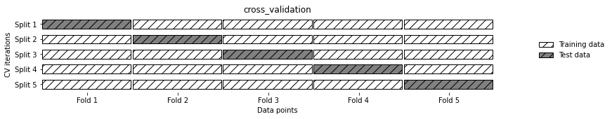

```python
mglearn.plots.plot_cross_validation()
```

### 1-1-2 교차 검증 실습

```python
from sklearn.model_selection import cross_val_score
from sklearn.datasets import load_iris
from sklearn.linear_model import LogisticRegression
```

```python
iris = load_iris()
logreg = LogisticRegression()
```

```python
import sklearn
print(sklearn.__version__)
```

```
0.23.1
```

- sklearn의 21버전은 cv(k폴더의 수)가 3으로 기본 지정
- sklearn의 22버전부터는 cv가 기본이 5으로 지정

```python
scores = cross_val_score(logreg, iris.data, iris.target)
print("교차 검증 점수 : {}".format(scores))
```

```
교차 검증 점수 : [0.96666667 1.         0.93333333 0.96666667 1.        ]
```

### 우리가 임의로 교차검증의 나눌 폴더수의 지정이 가능함. cv라는 매개변수를 이용하여 지정 가능.

```python
scores = cross_val_score(logreg, iris.data, iris.target, cv=5)
print("교차 검증 점수 : {}".format(scores))
```

```
교차 검증 점수 : [0.96666667 1.         0.93333333 0.96666667 1.        ]
```

```python
print("교차 검증 점수 : {:.2f}".format(scores.mean()))
```

```
교차 검증 점수 : 0.97
```

### 1-1-3 교차 검증의 장점

- 첫째, 데이터를 전반적으로 검증하는 여러개의 모델을 사용하기에 일반화된 모델을 생성할 수 있다.
- 둘째, 분할을 한번하는 것보다 데이터를 더 효율적으로 사용 가능.

### 교차 검증의 단점

- 주요 단점은 연산 비용이 늘어남. 모델을 k개를 만들어야 하므로 데이터를 한번 나눴을 때보다 k배가 더 느림.

### 1-1-4 계층별 k-겹 교차 검증에 대해 알아보기

- 데이터를 나눌 때, 순서대로 k개의 폴드로 나누는 것은 항상 좋은 것은 아니다.

```python
from sklearn.datasets import load_iris
iris = load_iris()
print("iris 레이블 :\n{}".format(iris.target))
```

```
iris 레이블 :
[0 0 0 0 0 0 0 0 0 0 0 0 0 0 0 0 0 0 0 0 0 0 0 0 0 0 0 0 0 0 0 0 0 0 0 0 0
 0 0 0 0 0 0 0 0 0 0 0 0 0 1 1 1 1 1 1 1 1 1 1 1 1 1 1 1 1 1 1 1 1 1 1 1 1
 1 1 1 1 1 1 1 1 1 1 1 1 1 1 1 1 1 1 1 1 1 1 1 1 1 1 2 2 2 2 2 2 2 2 2 2 2
 2 2 2 2 2 2 2 2 2 2 2 2 2 2 2 2 2 2 2 2 2 2 2 2 2 2 2 2 2 2 2 2 2 2 2 2 2
 2 2]
```

- 위의 데이터 처럼 3-겹 교차 검증을 적용한다고 할 때,
  - 첫번째는 클래스 0이고,
  - 두번째는 클래스 1이고,
  - 세번째는 클래스는 2이다.
    - 이런 데이터를 이용하여 모델을 만들고 평가하게 된다면 편향된 데이터로 인해 좋지 않은 모델이 나올 것이다.
- 단순한 k-겹 교차 검증은 문제가 발생. scikit-learn에서 계층별 교차 검증을 사용. ### 해결 => 계층별 교차 검증 : stratified k-fold cross-validation

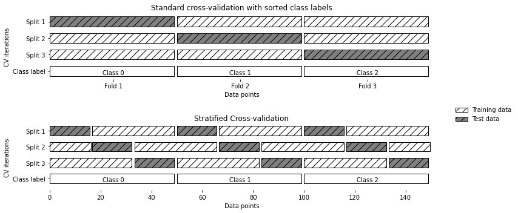

```python
mglearn.plots.plot_stratified_cross_validation()
```

- 계층별 교차 검증은 폴더 안에 클래스의 비율이 같도록 데이터를 나눈다.

### 일반적인 방법

- 분류에는 StratifiedKFold를 사용하며, 계층별 K-겹 교차 검증의 기본값이 잘 동작
- 회귀에는 단순한 KFold를 적용(k-겹 교차 검증)
  - KFold에서 shuffle 매개변수를 기본값 False 대신 True를 지정하면 폴더를 나누기 전에 무작위 섞는 것이 가능.
- cross_val_score함수를 사용시에는 KFold의 매개변수를 제어가 안되기에, KFold 객체를 만들어 cross_val_score함수의 cv의 매개변수로 전달해야 한다.
- model_selection 모듈에서 KFold 분할기를 임포트하고 원하는 폴더 수를 넣어 객체를 생성.

### 1-1-5 KFold 객체를 이용한 교차 검증

```python
from sklearn.model_selection import KFold
kfold = KFold(n_splits=5)

print("교차 검증 점수 : \n{}".format(cross_val_score(logreg,
                                               iris.data,
                                               iris.target,
                                               cv=kfold)))
```

```
교차 검증 점수 :
[1.         1.         0.86666667 0.93333333 0.83333333]
```

### iris 데이터 셋에서 3겹 교차 검증을 사용할 때,

- 점수가 0이 됨.

```python
kfold = KFold(n_splits=3)
print("교차 검증 점수 : \n{}".format(cross_val_score(logreg, iris.data, iris.target, cv=kfold)))
```

```
교차 검증 점수 :
[0. 0. 0.]
```

### iris 데이터 셋에서 3겹 교차 검증을 사용할 때,

- 계층별 폴더를 만드는 대신에 샘플의 순서를 뒤죽박죽으로 섞기(shuffle=True 로 준다.)
- random_state를 통해 데이터의 패턴을 고정하여 똑같은 작업을 재현이 가능

```python
kfold = KFold(n_splits=3, shuffle=True, random_state=0)
print("교차 검증 점수 : \n{}".format(cross_val_score(logreg, iris.data, iris.target, cv=kfold)))
```

```
교차 검증 점수 :
[0.98 0.96 0.96]
```

### 1-1-6 LOOCV (Leave-one-out cross-validation)

- 폴드 하나에 샘플 하나만 들어있는 k-겹 교차 검증
- 각 반복에 **하나의 데이터 포인트**를 선택해 **테스트 데이터 세트**로 사용.
- 데이터 셋이 클 경우 시간이 매우 오래 걸리지만, **작은 데이터 셋에서 이따금 좋은 결과**를 만든다.

```python
from sklearn.model_selection import LeaveOneOut
loo = LeaveOneOut()
scores = cross_val_score(logreg, iris.data, iris.target, cv=loo)
print("교차 검증 분할 횟수 : ", len(scores))
print("평균 정확도 : {:.2f}".format(scores.mean()))
```

```
교차 검증 분할 횟수 :  150
평균 정확도 : 0.97
```

- iris의 경우는 150개의 데이터이므로 150번의 교차 검증

### 1-1-7 임의 분할 교차 검증

- Shuffle-split cross-validation
- train_size 만큼의 포인트로 훈련 세트를 만들고, test_size만큼의 테스트 세트를 만든다.
- n_splits 횟수만큼 반복

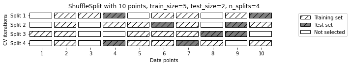

```python
mglearn.plots.plot_shuffle_split()
```

- 샘플이 10개, 5개는 학습용, 2개는 테스트용으로 4번 반복

```python
from sklearn.model_selection import ShuffleSplit
shuffle_split = ShuffleSplit(test_size=5, train_size=5, n_splits=10)

scores = cross_val_score(logreg, iris.data, iris.target, cv=shuffle_split)
print("교차 검증 점수 : \n{}".format(scores))
scores.mean()
```

```
교차 검증 점수 :
[0.8 0.4 0.8 0.6 0.8 0.8 0.6 1.  0.8 0.6]
```

```
0.72
```

### n_splits 를 15로 변경

```python
from sklearn.model_selection import ShuffleSplit
shuffle_split = ShuffleSplit(test_size=0.5, train_size=0.5, n_splits=15)

scores = cross_val_score(logreg, iris.data, iris.target, cv=shuffle_split)
print("교차 검증 점수 : \n{}".format(scores))
scores.mean()
```

```
교차 검증 점수 :
[0.97333333 0.97333333 0.96       0.93333333 0.97333333 0.92
 0.97333333 0.98666667 0.94666667 0.96       0.96       0.96
 0.92       0.96       0.94666667]
```

```
0.9564444444444447
```

#### ShuffleSplit 계층별 버전으로 StratifiedShuffleSplit 도 있음.

### 기타 검증

- GroupKFold : 그룹별 교차 검증
- 반복 교차 검증(RepeatedStratifiedKFold)

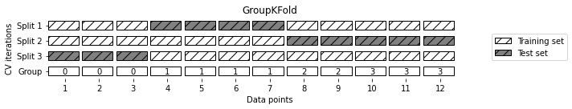

```python
mglearn.plots.plot_group_kfold()
```

### 1-1-8 반복 교차 검증

- 교차 검증을 반복하여 여러번 수행하는 경우가 많다.
  - 이를 위해 scikit-learn 0.19버전에서 RepeatedKFold와 RepeatedStratifiedKFold 분할기가 추가.
  - RepeatedStratifiedKFold는 StratifiedKFold클래스를 사용합니다. 분할 폴드 수는 n_splits 매개변수로 설정하며 기본값은 5이다. 반복 횟수는 n_repeats 매개변수로 설정. 기본값은 10이다.

```python
from sklearn.model_selection import cross_val_score, KFold, StratifiedKFold
from sklearn.datasets import load_iris
from sklearn.linear_model import LogisticRegression

iris = load_iris()
logreg = LogisticRegression()
```

```python
from sklearn.model_selection import RepeatedStratifiedKFold
```

```python
rskfold = RepeatedStratifiedKFold(random_state=42)
scores = cross_val_score(logreg, iris.data, iris.target, cv=rskfold)

print("교차 검증 점수 : ",  scores)
print("교차 검증 평균 점수 : {:.3f}".format(scores.mean() ) )
```

```
교차 검증 점수 :  [1.         0.96666667 0.93333333 1.         0.93333333 0.96666667
 0.96666667 0.93333333 1.         0.96666667 0.93333333 1.
 1.         0.96666667 0.96666667 0.9        1.         1.
 0.93333333 0.96666667 0.93333333 0.96666667 0.96666667 1.
 0.96666667 1.         0.96666667 0.96666667 0.9        1.
 0.96666667 0.96666667 0.96666667 0.96666667 0.93333333 0.96666667
 0.96666667 1.         1.         0.9        0.96666667 1.
 0.9        0.96666667 0.96666667 0.9        0.96666667 0.96666667
 1.         0.96666667]
교차 검증 평균 점수 : 0.965
```

- 전체 검증 점수는 n_splits X n_repeats개수만큼 만들어진다. 기본값을 사용하여 만들경우 5 x 10 = 50개의 모델이 만들어진다.